# L02-4-2D

# Assignment Instructions

Rename with your name in place of Studentname and make your edits and updates here.

If you need to start from scratch, use Kernel > Restart & Clear Output

# Scatterplots with Categorical Variables

When we can identify variables as categorical or non-categorical, we can then use the categorical variables differently to show the categorization of the other variables.

Categorical variables are variables with limited number of values. We will look at the now familiar fuel economy vs. displacement, and add categorical information to them to reveal more patterns.

Jitter and alpha transparency blending help with overplotting of categorical variables. Both jitter and alpha used static parameters. For example, alpha = 0.5 meant that each point was 50% transparent. That 50% was independent of the data. In other words, it was 0.5 for every point regardless of the value of that point. A powerful feature of ggplot is mapping data columns to aesthetics. Technically when we map columns to the x and y parameters, we are already doing this. Notice that it is inside the mapping = aes() function. There are many more aesthetics than just x and y. Color is a great example. Imagine the color of a point changing based upon the number of cylinders.

In some situations when the underlying data appears to be a continuous variable, the color scale will be a continuous range. A way to indicate that the variable is categorical is to wrap it with as.factor().

## R Features

- library()
- glimpse()
- ggplot()
- geom_jitter()
- geom_smooth()
- as.factor()
- facet_wrap()
- facet_grid()

## Datasets

- mpg

```r
# Load the tidyverse library
library(tidyverse)

library(repr)
options(repr.plot.width=4, repr.plot.height=4)
```

```r
# Explore the data
# Dataframe: mpg
glimpse(mpg)
```

```
Observations: 234
Variables: 11
$ manufacturer <chr> "audi", "audi", "audi", "audi", "audi", "audi", "audi"...
$ model        <chr> "a4", "a4", "a4", "a4", "a4", "a4", "a4", "a4 quattro"...
$ displ        <dbl> 1.8, 1.8, 2.0, 2.0, 2.8, 2.8, 3.1, 1.8, 1.8, 2.0, 2.0,...
$ year         <int> 1999, 1999, 2008, 2008, 1999, 1999, 2008, 1999, 1999, ...
$ cyl          <int> 4, 4, 4, 4, 6, 6, 6, 4, 4, 4, 4, 6, 6, 6, 6, 6, 6, 8, ...
$ trans        <chr> "auto(l5)", "manual(m5)", "manual(m6)", "auto(av)", "a...
$ drv          <chr> "f", "f", "f", "f", "f", "f", "f", "4", "4", "4", "4",...
$ cty          <int> 18, 21, 20, 21, 16, 18, 18, 18, 16, 20, 19, 15, 17, 17...
$ hwy          <int> 29, 29, 31, 30, 26, 26, 27, 26, 25, 28, 27, 25, 25, 25...
$ fl           <chr> "p", "p", "p", "p", "p", "p", "p", "p", "p", "p", "p",...
$ class        <chr> "compact", "compact", "compact", "compact", "compact",...
```

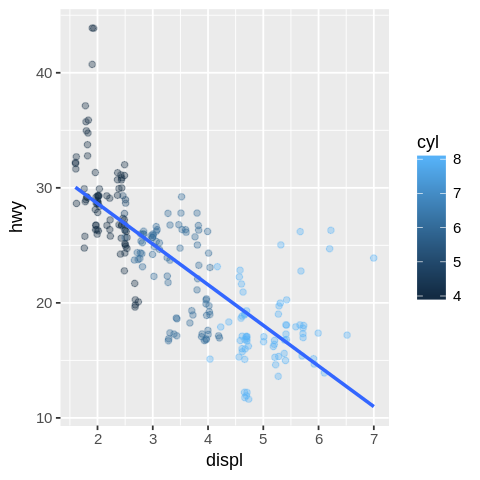

```r
# Start with a baseline plot
# Scatterplot mpg: hwy vs displ
# +jitter; +alpha; +trend
ggplot(data = mpg, mapping = aes(x = displ, y = hwy, color = cyl)) +
   geom_jitter(alpha = .35) +
   geom_smooth(method = 'lm', se = FALSE)
```

```r
?aes
```

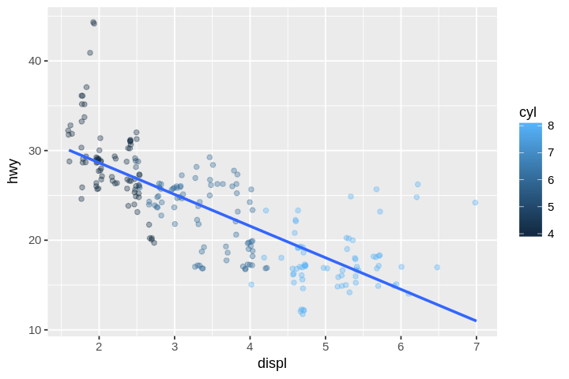

```r
# Map color to cyl

# Scatterplot mpg: hwy vs displ
# +jitter; +alpha; +trend
# Since we have no reason not to inherit color to all geoms
# just like data, x, and y, so we map the color in ggplot
# Be sure to add it into the aes area and separate it by a comma
options(repr.plot.width=6, repr.plot.height=4)
ggplot(data = mpg, mapping = aes(x = displ, y = hwy, color = cyl)) +
   geom_jitter(alpha = .35) +
   geom_smooth(method = 'lm', se = FALSE)


# Notice that 8 cylinders are toward the right and 4 cylinders are toward the left
# Since the variable was a number, ggplot defaulted it to a continuous variable
# and made the colors continuous from light to dark
# That is hard to analyze and it isn't appropriate for a categorical variable
```

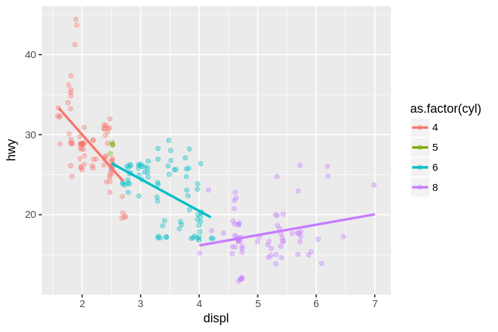

```r
# Change cyl to a categorical variable
# Scatterplot mpg: hwy vs displ
# +jitter; +alpha; +trend; +color = cyl
# Change cyl to a categorical variable
# so ggplot will use more distinct colors
# One way is to wrap the variable in as.factor()

ggplot(data = mpg, mapping = aes(x = displ, y = hwy, color = as.factor(cyl))) +  # Don't forget the closing parenthesis
   geom_jitter(alpha = .35) +
   geom_smooth(method = 'lm', se = FALSE)

# Now we get more distinct colors making it much easier to analyze
# Also notice as a side effect of inheriting the color mapping to all geoms
# that geom_smooth got the color mapping too.
# So it calculated a linear trend line for each category of cyl
# Take a look at the 8 cylinder trend line. Interesting.
```

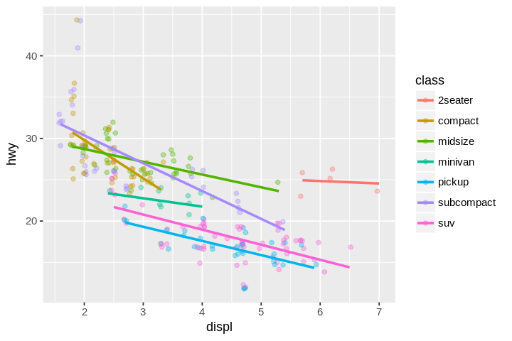

```r
# Let's try another variable, class instead of cyl

# Scatterplot mpg: hwy vs displ
# +jitter; +alpha; +trend; +color = class
# Change cyl to class and remove the as.factor()
# since ggplot already knows it is a categorical variable
# because the data type is character string
ggplot(data = mpg, mapping = aes(x = displ, y = hwy, color = class)) +
   geom_jitter(alpha = .35) +
   geom_smooth(method = 'lm', se = FALSE)

# Now things are getting more interesting
# It is clear now that the upward slope for 8 cylinders
# Might be due to 2 seater sports cars.
# It would be good to confirm that these have 8 cylinder engines
```

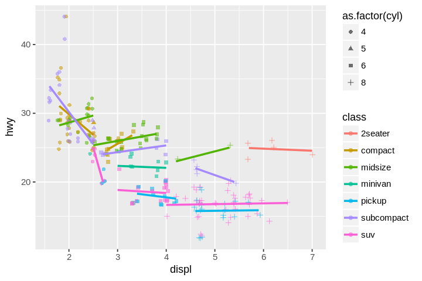

```r
# Let's add cyl back in mapped to shape

# Scatterplot mpg: hwy vs displ
# +jitter; +alpha; +trend;
# +color = class; +shape = cyl
# Change cyl to class and remove the as.factor()
# since ggplot already knows it is a categorical variable
# because the data type is character string
ggplot(data = mpg, mapping = aes(x = displ, y = hwy, color = class, shape = as.factor(cyl))) +  # Count those parenthesis
   geom_jitter(alpha = .55) +
   geom_smooth(method = 'lm', se = FALSE)

# Confirmed. The 2-seater cars have 8 cylinder engines
# These trend lines are getting out of control now.
# The visual is getting too busy for my brain to handle
```

As you can see, mapping categorical variables is easy and very helpful for analysis. I look for these first in the dataset. Also, as we found, we can quickly over do it with information overload in a single plot. And we haven't even scratched the surface yet at the number of geoms and aesthetics that are at our disposal.

A way to handle visual overload is by having more plots. Of course we have been doing this throughout this course in different Jupyter cells, but here I mean a group of plots that are related to each other in some way. Plotting them next to each other or with the same axis ranges may yield some analytical insights that would be harder to spot in more visually seperated plots.

ggplot has two functions to create a group of related plot. facet_wrap() and facet_grid(). They are added to the plot as another layer just like the geoms. facet_wrap() takes one categorical variable and instead of plotting all the categories in a single plot, it creates a smaller plot for each category. The reason it is called wrap is because it creates them as one long row and then wraps large rows onto the next row just like text wraps in a document when it exceeds the margin.

facet_grid() on the other hand doesn't wrap and you can specify whether you want a single row or a single column of plots. The real power of facet_grid() comes in because it allows you to specify two categorical variables, one for the rows and another for the columns. This provides a matrix or grid of plots that include the interactions with both.

facet_wrap() and facet_grid() use R's formula syntax which may seem pretty strange. At this point, we aren't working with all the features of formulas so all we need to know is just a bit of syntax which is the use of the tilde '~'. For facet_wrap() prefice the categorical variable with a ~ and for facet_grid put use row_variable ~ column_variable. If you just want one variable for facet_grid then replace the other with a period '.'.

```r
# Let's get into the habit of seeing the usage help on new functions
help(facet_wrap)
```

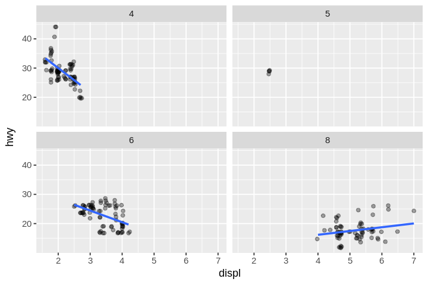

```r
# Let's use facet_wrap for cyl

# Scatterplot mpg: hwy vs displ
# +jitter; +alpha; +trend;
# facet = cyl
# Add facet_wrap() using the plus chain operator
# The method for passing in the value uses
# R's formula method. This includes a ~ followed
# by the variable name like ~ cyl
# We don't have to explicitly cast it with as.factor
# since facet wrap just uses the values directly

ggplot(data = mpg, mapping = aes(x = displ, y = hwy)) +
   geom_jitter(alpha = .35) +
   geom_smooth(method = 'lm', se = FALSE) +
   facet_wrap(~cyl)

# Notice how the x and y axis are shared by the plot
# Having a shared scale can reveal insights
# Look at the slope of trend lines
# Notice that different cylinder engines
# affect fuel efficiency differently in relation to
# engine displacement
# Yes, I really want to filter out the 5 cylinder vehicles
# We will learn how to do this soon.
```

```r
?color
```

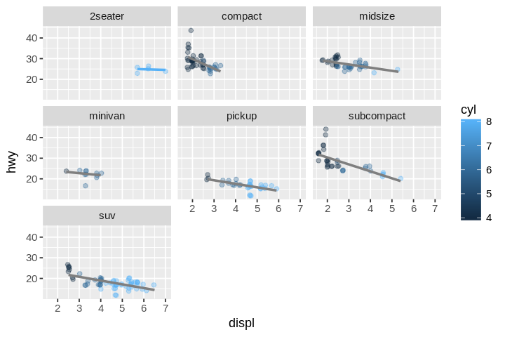

```r
# Let's use facet_wrap for class

# Scatterplot mpg: hwy vs displ
# +jitter; +alpha; +trend;
# facet = class
# Add facet_wrap() using the plus chain operator
# The method for passing in the value uses
# R's formula method. This includes a ~ followed
# by the variable name like ~ class

ggplot(data = mpg, mapping = aes(x = displ, y = hwy, color = cyl)) +
  geom_jitter(alpha = .35) +
  geom_smooth(method = 'lm', se = FALSE) +
  facet_wrap(~class)

# Notice that slope for all vehicle classes are down
# yet when for 8 cylinder vehicles it is a positive slope
```

```r
# Let's check out the help for facet_grid()
?facet_grid
```

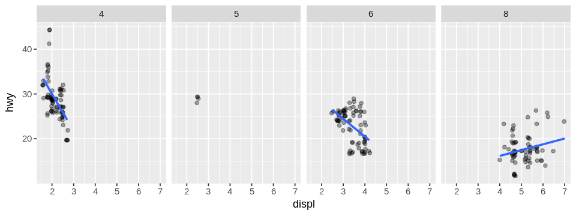

```r
# Let's use facet_grid for cyl as columns only

# Scatterplot mpg: hwy vs displ
# +jitter; +alpha; +trend;
# facet column = cyl
# Add facet_grid() using the plus chain operator
# The method for passing in the value uses
# R's formula method. This includes a ~
# separating the row variable and the column variable
# with a period to denote no variable like . ~ cyl
options(repr.plot.width=8, repr.plot.height=3)
ggplot(data = mpg, mapping = aes(x = displ, y = hwy)) +
   geom_jitter(alpha = .35) +
   geom_smooth(method = 'lm', se = FALSE) +
   facet_grid(. ~ cyl)

# Notice how much more pronounced the slopes are
# with this x and y plot perspective
# be careful with perspective since it can alter
# your analytical thinking.
```

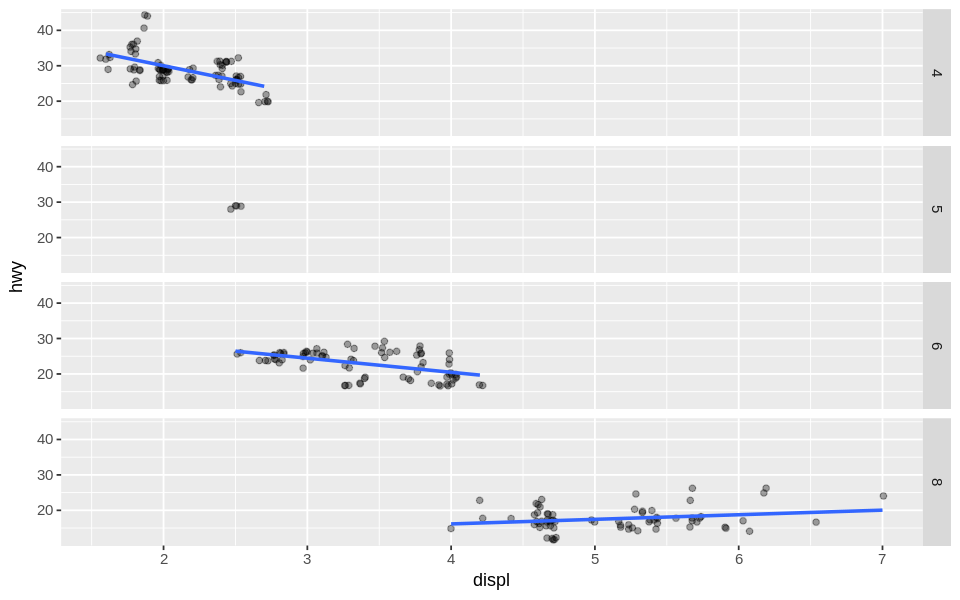

```r
# Contrast this by faceting cyl as rows

# Scatterplot mpg: hwy vs displ
# +jitter; +alpha; +trend;
# facet column = cyl
# Add facet_grid() using the plus chain operator
# The method for passing in the value uses
# R's formula method. This includes a ~
# separating the row variable and the column variable
# with a period to denote no variable like . ~ cyl
options(repr.plot.width=8, repr.plot.height=5)

ggplot(data = mpg, mapping = aes(x = displ, y = hwy)) +
   geom_jitter(alpha = .35) +
   geom_smooth(method = 'lm', se = FALSE) +
   facet_grid(cyl ~ .)

# The slopes seem less aggressive now
# Aside from the aspect ratio, the choice
# of columns vs rows reveals the relationship of
# one or the other more clearly
# cyl as columns shows how hwy decreases
# as cyl increases
# cyl as rows shows the clustering of displacement
# by cyl for example, 4 cyl vehicles are 1 - 3 liter engines
# with a little overlap with 6 cyl engines
```

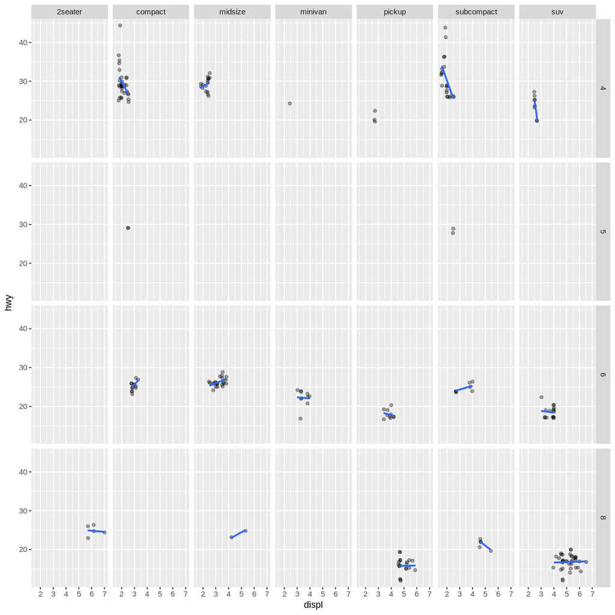

```r
# Facet by both cyl and class

# Scatterplot mpg: hwy vs displ
# +jitter; +alpha; +trend;
# facet row = cyl
# facet col = class
# Add facet_grid() using the plus chain operator
# The method for passing in the value uses
# R's formula method. This includes a ~
# separating the row variable and the column variable
# with a period to denote no variable like cyl ~ class
options(repr.plot.width=10, repr.plot.height=10)

ggplot(data = mpg, mapping = aes(x = displ, y = hwy)) +
   geom_jitter(alpha = .35) +
   geom_smooth(method = 'lm', se = FALSE) +
   facet_grid(cyl ~ class)

# Notice we can easily see the effects of
# hwy and displ have for each class and cyl
```

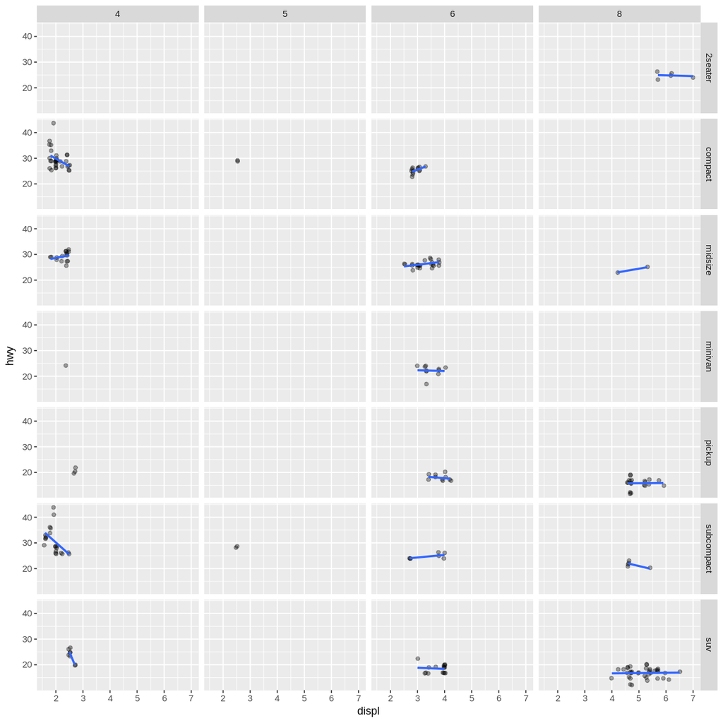

```r
# Facet by both cyl and class
# this time switch rows and columns

# Scatterplot mpg: hwy vs displ
# +jitter; +alpha; +trend;
# facet row = class
# facet col = cyl
# Add facet_grid() using the plus chain operator
# The method for passing in the value uses
# R's formula method. This includes a ~
# separating the row variable and the column variable
# with a period to denote no variable like cyl ~ class

options(repr.plot.width=10, repr.plot.height=10)

ggplot(data = mpg, mapping = aes(x = displ, y = hwy)) +
   geom_jitter(alpha = .35) +
   geom_smooth(method = 'lm', se = FALSE) +
   facet_grid(class ~ cyl)

# Although a matter of preference,
# But patterns like 2 seater is 8 cylinder only
# stand out to me much more in this configuration
# It doesn't hurt to plot multiple ways
```

Let's put all the lines of code together to see the bigger picture of what we ended up with. But first, did you notice that when we used facet_wrap() and facet_grid() that we didn't type the name of the parameter, facets. It certainly would work if we did, but usually the first parameter of a function is the most important one and as we start remembering what they are, we don't need to remind ourselves by typing them in every time. This can improve code readability. On the flip side, it is possible to specify all the parameters, by position as it is called, and not type any of the parameter names. This could make the code much harder to understand, forcing the programmer to count the position of the parameter and consult the usage help.

So, we will slowly move to not specifying the parameter names for the first one or two parameter values of a function, and continue to specify names for the other ones.

As we consolidate the code below, let me remove the 'data =' from our ggplot function. We should remember that the first parameter is the data paramater without having to call it out specifically.

In your code, you are welcome to do what you find most comfortable.

```
Observations: 234
Variables: 11
$ manufacturer <chr> "audi", "audi", "audi", "audi", "audi", "audi", "audi"...
$ model        <chr> "a4", "a4", "a4", "a4", "a4", "a4", "a4", "a4 quattro"...
$ displ        <dbl> 1.8, 1.8, 2.0, 2.0, 2.8, 2.8, 3.1, 1.8, 1.8, 2.0, 2.0,...
$ year         <int> 1999, 1999, 2008, 2008, 1999, 1999, 2008, 1999, 1999, ...
$ cyl          <int> 4, 4, 4, 4, 6, 6, 6, 4, 4, 4, 4, 6, 6, 6, 6, 6, 6, 8, ...
$ trans        <chr> "auto(l5)", "manual(m5)", "manual(m6)", "auto(av)", "a...
$ drv          <chr> "f", "f", "f", "f", "f", "f", "f", "4", "4", "4", "4",...
$ cty          <int> 18, 21, 20, 21, 16, 18, 18, 18, 16, 20, 19, 15, 17, 17...
$ hwy          <int> 29, 29, 31, 30, 26, 26, 27, 26, 25, 28, 27, 25, 25, 25...
$ fl           <chr> "p", "p", "p", "p", "p", "p", "p", "p", "p", "p", "p",...
$ class        <chr> "compact", "compact", "compact", "compact", "compact",...
```

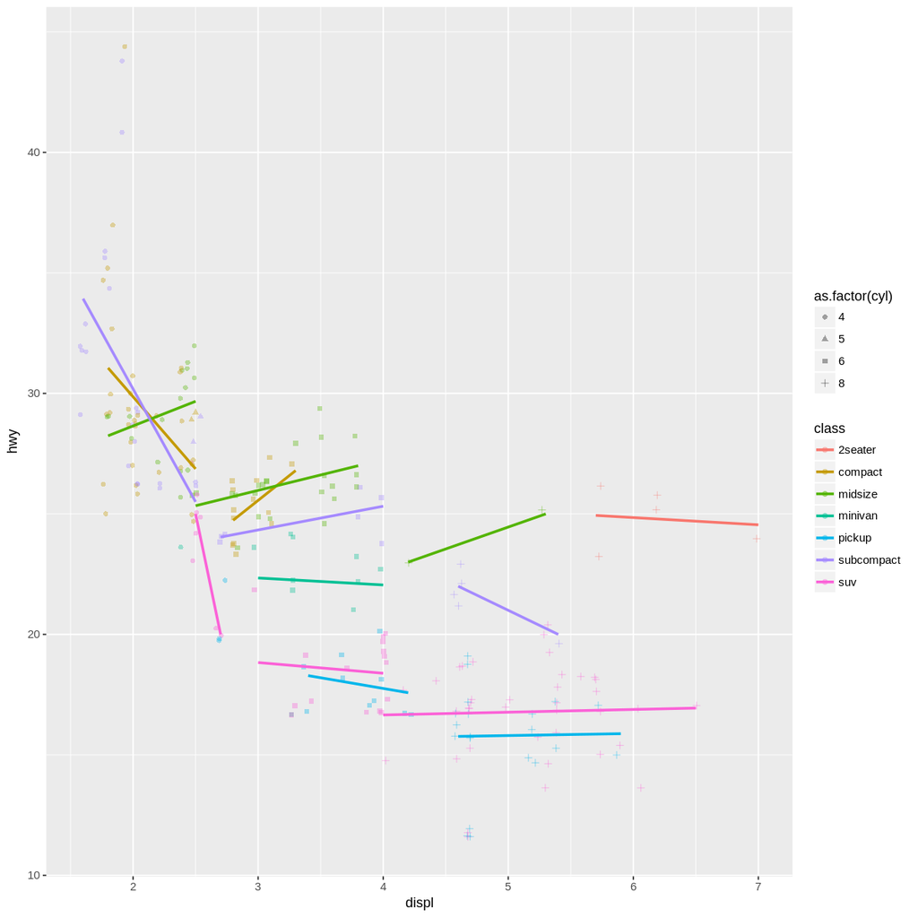

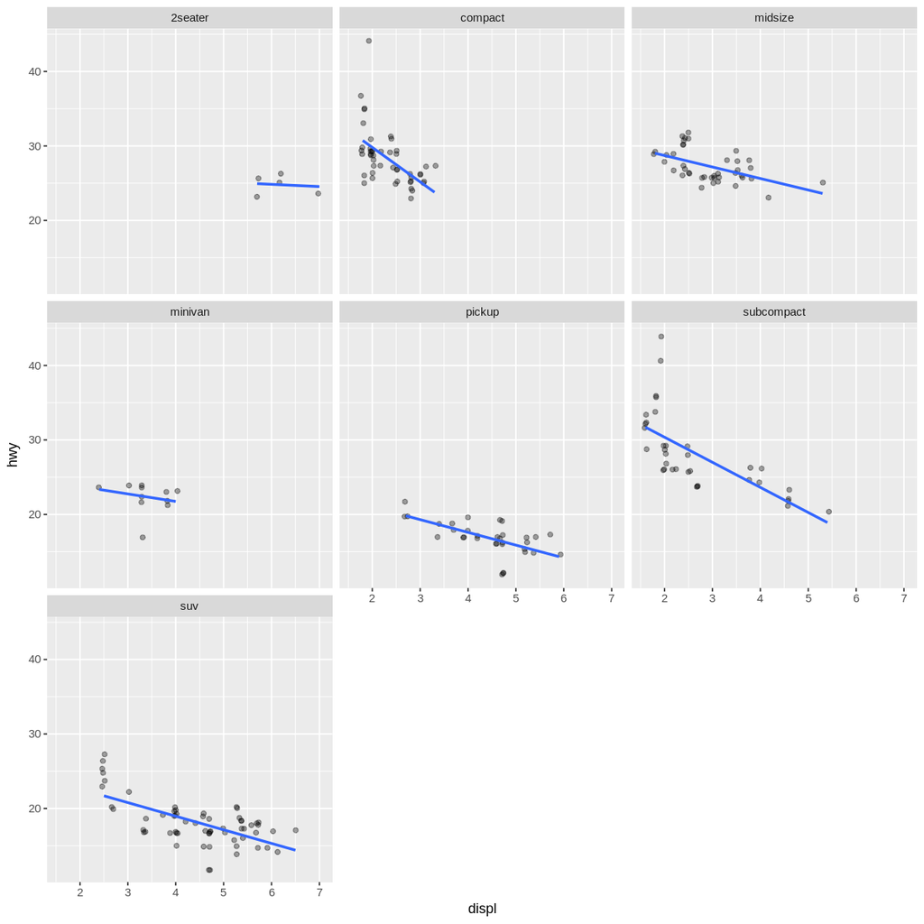

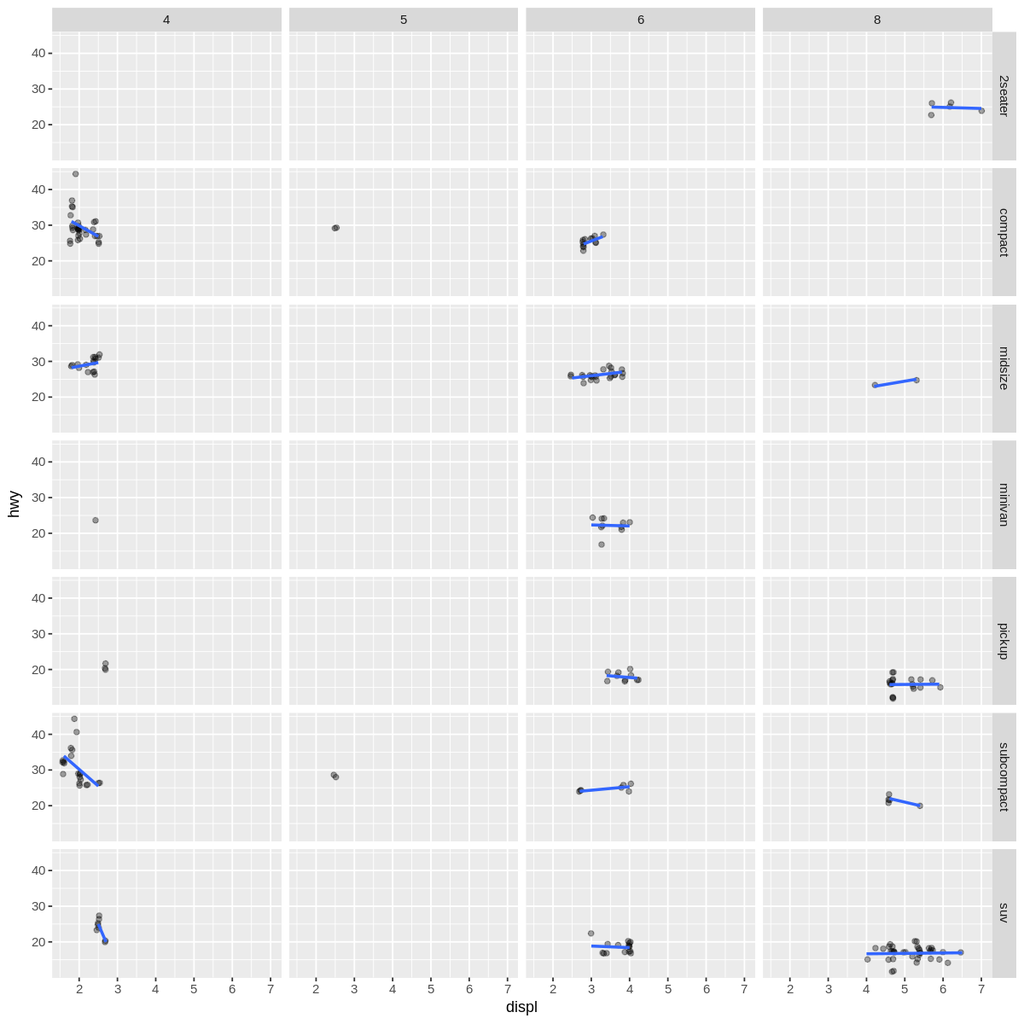

```r
# Load libraries
library(tidyverse)

# Explore data structure
glimpse(mpg)

# hwy vs displ with class color and cyl shape
ggplot(mpg, mapping = aes(x = displ, y = hwy, color = class, shape = as.factor(cyl))) +
   geom_jitter(alpha = .35) +
   geom_smooth(method = 'lm', se = FALSE)

# hwy vs displ facet wrap by class
ggplot(mpg, mapping = aes(x = displ, y = hwy)) +
   geom_jitter(alpha = .35) +
   geom_smooth(method = 'lm', se = FALSE) +
   facet_wrap(~ class)

# hwy vs displ facet grid by class and cyl
ggplot(mpg, mapping = aes(x = displ, y = hwy)) +
   geom_jitter(alpha = .35) +
   geom_smooth(method = 'lm', se = FALSE) +
   facet_grid(class ~ cyl)
```